# Christmas Bird Counts

Sam Taylor

18/06/2019

Every year around Christmas time, since 1921, birdwatchers in the Hamilton area of Ontario have gone out and counted all the birds they see or hear in a day.

They have been carefully recording this data, and the raw data is available through the website of Bird Studies Canada (twitter handle: @BirdsCanada).

Sharleen has been a part of this data collection for the past two years, and decided to do some citizen data science with it! She went through and cleaned this data and made it much more ready for analysis! She detailed her data journey in a 5 part blog series as seen here. Many thanks to her for cleaning, visualizing, and then sharing it!

Data is available at https://github.com/rfordatascience/tidytuesday/tree/master/data/2019/2019-06-18

NB. The focus of this analysis is determing if the hours spent counting birds results in a higher number of birds count. Consequentally, for the purposes of this analysis missing values have been excluded.

## How have overall bird numbers and hours spent watching them changed over time?

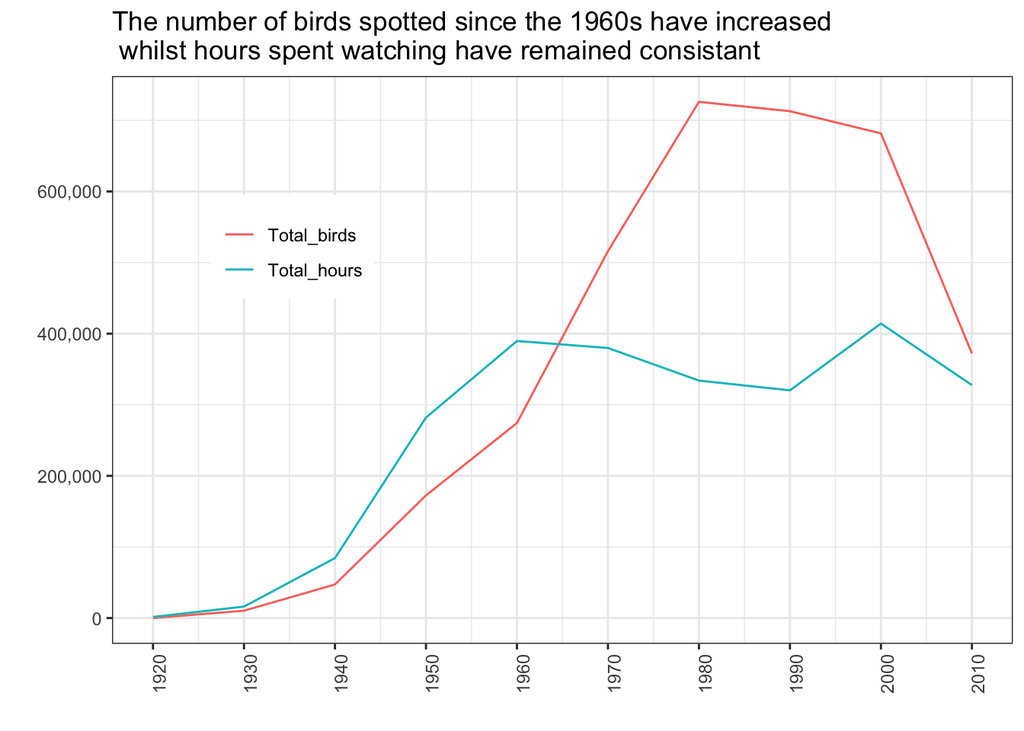

## What are the most common species of birds and how long are they watched for?

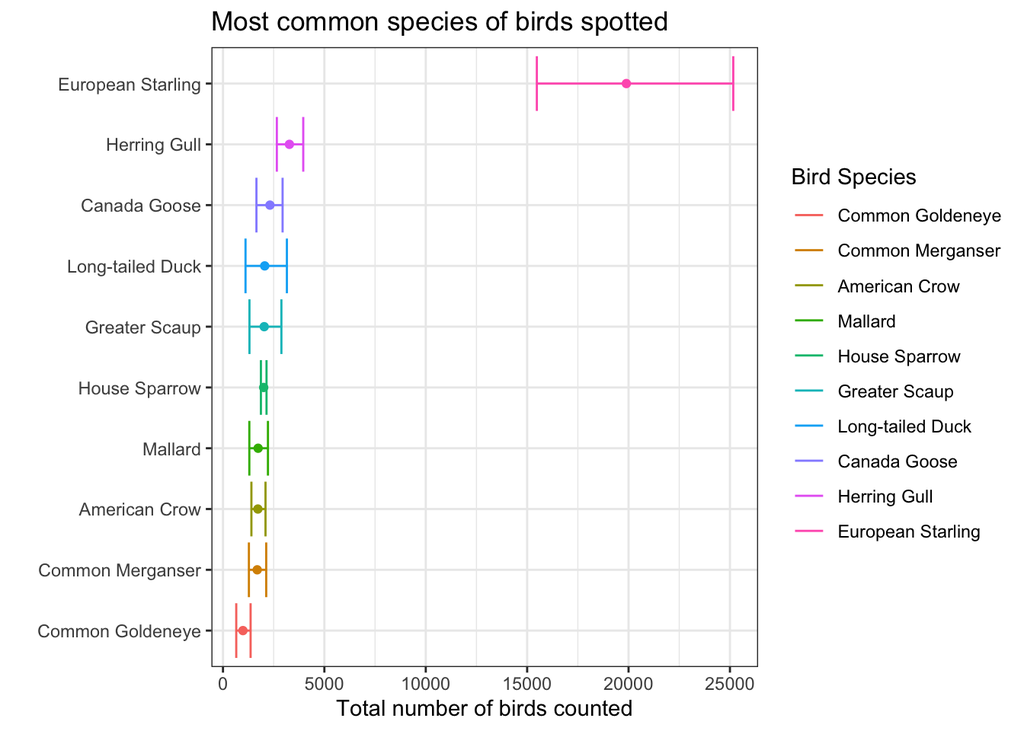

Interestingly, when the dataset is filtered for the most common birds in they consistantly have the same number of hours dedicate to watching them - part of a research project perhaps?

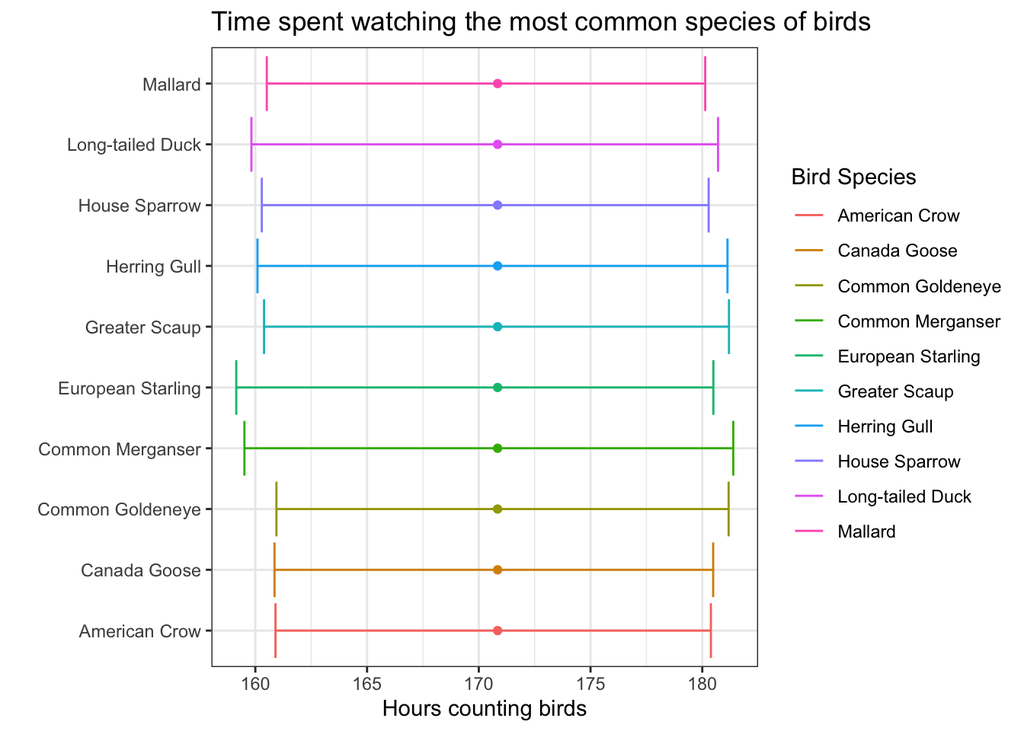

## Does the number of hours spent watching birds increase the number of birds counted?

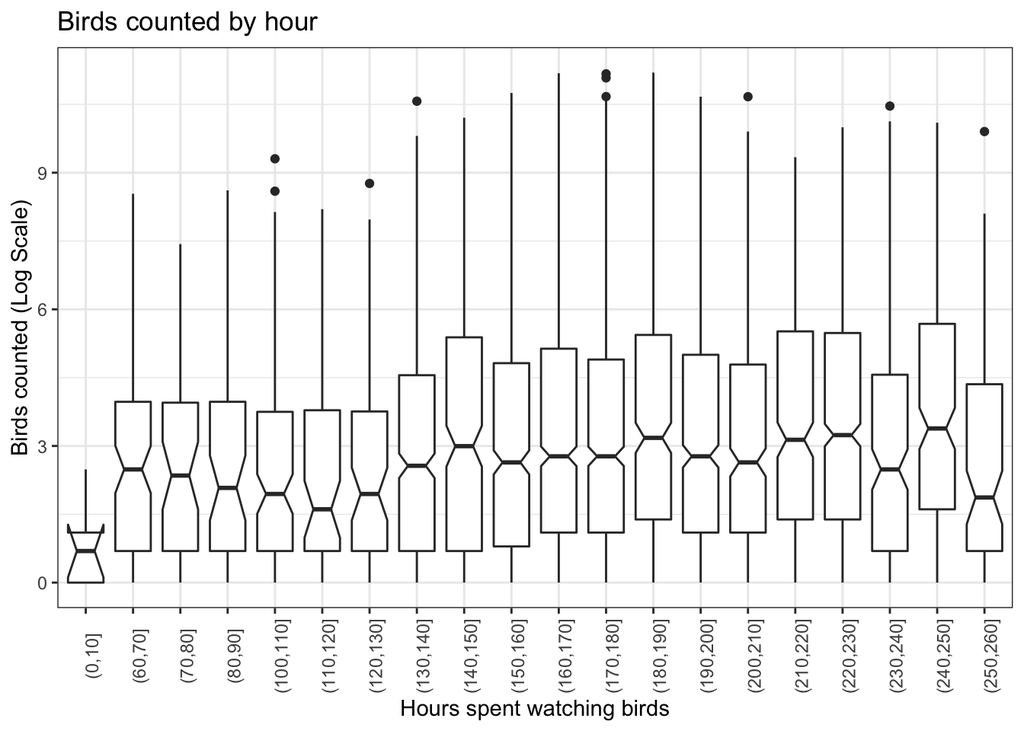

```
##
## Call:
## lm(formula = how_many_counted ~ total_hours, data = bird_counts_processed)
##
## Residuals:
##    Min     1Q Median     3Q    Max
##   -351   -267   -226   -169  72743
##
## Coefficients:
##             Estimate Std. Error t value Pr(>|t|)
## (Intercept) -10.2371    68.8052  -0.149 0.881726
## total_hours   1.4378     0.3891   3.695 0.000221 ***
## ---
## Signif. codes:  0 '***' 0.001 '**' 0.01 '*' 0.05 '.' 0.1 ' ' 1
##
## Residual standard error: 2168 on 14923 degrees of freedom
## Multiple R-squared:  0.0009141,  Adjusted R-squared:  0.0008471
## F-statistic: 13.65 on 1 and 14923 DF,  p-value: 0.0002206
```